# Introduction to Regression

Corinne Riddell (Instructor: Alan Hubbard)

September 6, 2023

# Learning objectives for today

1. Introduction to linear regression
   - How do we find the line of best fit?
   - What is its slope?
   - What is its intercept?
   - What is the R-squared?
2. Use R to run a linear regression and add a regression line to a scatter plot
3. Learn how to transform non-linear data so that we can use linear regression
4. Learn how outliers influence the line of best fit
5. Understand why:
   - Association does not necessarily mean causation
   - We should not extrapolate beyond our data
   - We should always consider potential **confounders** in our interpretation
   - We should use data visualization to confirm the shape of the relationship

# Readings

- Chapter 4 of Baldi & Moore
- [Simple Linear Regression](https://moderndive.com/5-regression.html) (See section 5.1.2)
- [R Squared](https://statsthinking21.github.io/statsthinking21-core-site/the-general-linear-model.html#linear-regression) (See section 14.1.5)

# What is a regression line?

- A straight line that is **fitted** to data to minimize the distance between the data and the fitted line.
- It is often called the **line of best fit**.
- It is also called the **least-squares regression line** (sometimes refered to as **ordinary least squares** or **OLS**) this is because, mathematically, the criteria for choosing this line is based on the sum of squares of the vertical distances from the line. We choose the line that minimizes this sum.

# What is a regression line?

Once we calculate this line, it can be used to describe the relationship between the explanatory and response variables.

- *Can* you fit a line of best fit for non-linear relationships? *Should* you?
- Very important to visualize the relationship first. Why?

# Equation of the line of best fit

The line of best fit can be represented by the equation for a line:

$$y = a + bx$$

where $a$ is the **intercept** and $b$ is the **slope**.

This equation encodes a lot of useful information.

Note: You might have learned this as: $y = mx + b$, where $b$ is the intercept and $m$ is the slope. In this class we use the previous notation (shown above), but all the same concepts apply.

# Equation of the line of best fit: the intercept

$$y = a + bx$$

If $x=0$, the equation says that $y=a$. That is, the line of best fit crosses the y-axis at the value $a$. That is, $a$ is where the line of best intercepts the y-axis, hence, it is the intercept.

- Is the value of the intercept always meaningful?

# Equation of the line of best fit: the slope

$$y = a + bx$$

$b$ is known as the slope because an increase from $x$ to $x+1$ is associated with an increase in $y$ by the amount $b$.

The slope can also be writted as a function of the correlation coefficient which we talked about last class:

$$b=r\frac{s_y}{s_x}$$
Where $r$ is the correlation coefficient, $s_y$ is the standard deviation of the $y$ variable and $s_x$ is the standard deviation of the $x$ variable.

Note that this means that the correlation coefficient and the slope will always have the same sign (e.g., if the correlation is positive then b will also be positive)

# The R-squared value

- The $r^2$ value or R-squared, is the fraction of the variation in the values of $y$ that is explained by the regression of $y$ on $x$
- If all points in a scatter plot between X and Y fall exactly on the regression line, the value of $r^2$ is 1.
- Note that $r^2$ is the correlation coefficient squared

# Fitting a linear model in R

**Code to run a linear model:** `lm(y ~ x, data = your_data)`

- `lm()` is the function for a linear model.
- The first argument that `lm()` wants is a **formula**: `y ~ x`.
  - `y` is the **response variable** from your dataset/what you are trying to predict
  - `x` is the **explanatory variable**/what you are using to make a prediction
  - be careful with the order of x and y! It is opposite from the default order in ggplot when we write `ggplot(data, aes(x = your_x, y = your_y))`
- The second argument sent to `lm()` is the data set.
  - the default order or declaring the data as the second argument in `lm()` is different from `ggplot2` and `dplyr` functions

# Fitting a linear model in R

Code template:

```r
# Students, if you copy this code chunk, you need to set eval = T in the code chunk header for the code to compile

your_lm <- lm(formula = y ~ x, data = your_dataset)

library(broom) # This package makes the output from the linear model look clean
tidy(your_lm) # This function from the broom package tidies up the output that is printed to the screen
```

# Why the package broom?

[figure not shown]

- `broom` has functions that make the output from the linear model look clean
- `tidy` is a function from the `broom` package that tidies up the output

```r
# Students, if you copy this code chunk, you need to set eval = T in the code chunk header for the code to compile

your_lm <- lm(formula = y ~ x, data = your_dataset)

library(broom)
tidy(your_lm)
```

# Manatee deaths and powerboat registrations

Let’s apply the `lm()` function. Recall the manatee example from Ch.3 that examined the relationship between the number of registered `powerboats` and the number of manatee `deaths` in Florida between 1977 and 2016.

- Recall that the relationship was linear by examining the scatter plot
- This is the relationship between number of powerboat registrations (in thousands) and manatee deaths (see page 70 of the textbook)

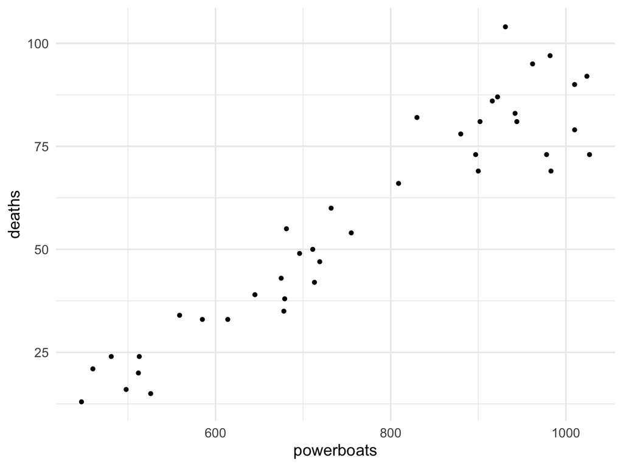

```r
library(ggplot2)
ggplot(mana_data, aes(x = powerboats, y = deaths)) +
  geom_point() +
  theme_minimal(base_size = 15)
```

# lm() of manatee deaths and powerboat purchases

Calculate the line of best fit:

```r
mana_lm <- lm(deaths ~ powerboats, mana_data)

library(broom)
tidy(mana_lm)
```

```
## # A tibble: 2 × 5
##   term        estimate std.error statistic  p.value
##   <chr>          <dbl>     <dbl>     <dbl>    <dbl>
## 1 (Intercept)  -46.8     6.03        -7.75 2.43e- 9
## 2 powerboats     0.136   0.00764     17.8  5.21e-20
```

- Only pay attention to the “term” and “estimate” columns for now.

**Interpret the model output**

- **Intercept**: The predicted number of deaths if there were no powerboat registrations. But the prediction is negative. Why?
- **powerboats**: This is the **slope** of the line. It is labelled “powerboats” because in more advanced models we can have multiple `X` explanatory variables and have a slope for each one.
- Question: What does the estimated slope for powerboats mean? Remember that the variable `powerboats` needs to be multiplied by 1000 – e.g., if it says that powerboats=447 this means that 447*1000 = 447,000 powerboats were registered in that year.

# Interpret the model output

- Question: What does the estimate slope for powerboats mean? Remember that the variable `powerboats` needs to be multiplied by 1000 – e.g., if it says that powerboats=447 this means that 447*1000 = 447,000 powerboats were registered in that year.
- Answer: A one unit change in the number of powerboats registered (multiplied by 1,000) is associated with an increase of manatee deaths of 0.1358. That is, a 1000-unit increase in the number of powerboats registered is associated with 0.1358 more manatee deaths.

# Check your understanding!

If powerboat registration increased by 100,000 how many more manatee deaths are expected?

# Add the regression line to the scatter plot using `geom_abline()`

- What parameters do we pass `geom_abline()`?
- Notice that we cannot see the y intercept in this plot. This is because ggplot only shows the plotting region that corresponds to the range of the data. Here, the range of the data is far from where x=0, so we cannot see where the line of best fit crosses the y axis.

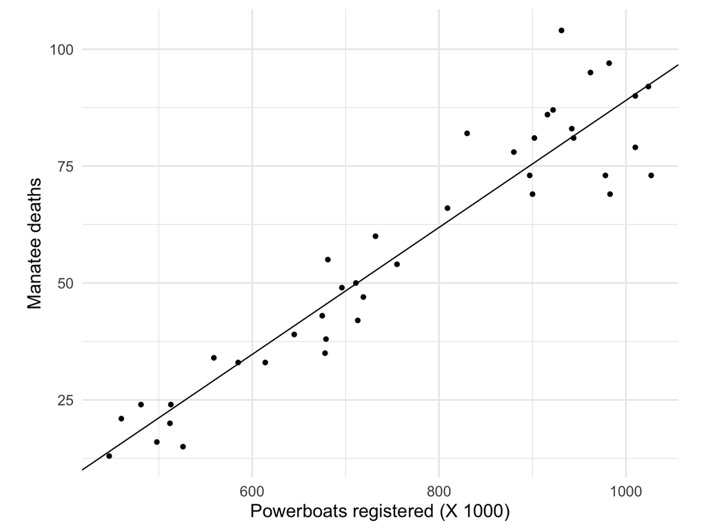

```r
# students, know how to use geom_abline() to add a line to scatterplot
# students do not need to know the coord_fixed command.

default_zoom_plot <- ggplot(mana_data, aes(x = powerboats, y = deaths)) +
  geom_point() +
  labs(x = "Powerboats registered (X 1000)",
       y = "Manatee deaths") +
  geom_abline(intercept = -46.7520, slope = 0.1358) +
  coord_fixed(ratio = 5) +
  theme_minimal(base_size = 15)

default_zoom_plot
```

# Change the plotting region to show the y intercept

- We can add `scale_x_continuous(limits = c(0, 1050))` to the ggplot to tell y to show a range of data going from `x=0` to `x=1050.`
- Now we can see the intercept estimate. It is where the line of best fit intersects the y axis. Should we interpret it?
- It is far from the bulk of the data, there is no data near powerboats = 0
- Interpretation would be **extrapolation**, which is **not supported** by these data

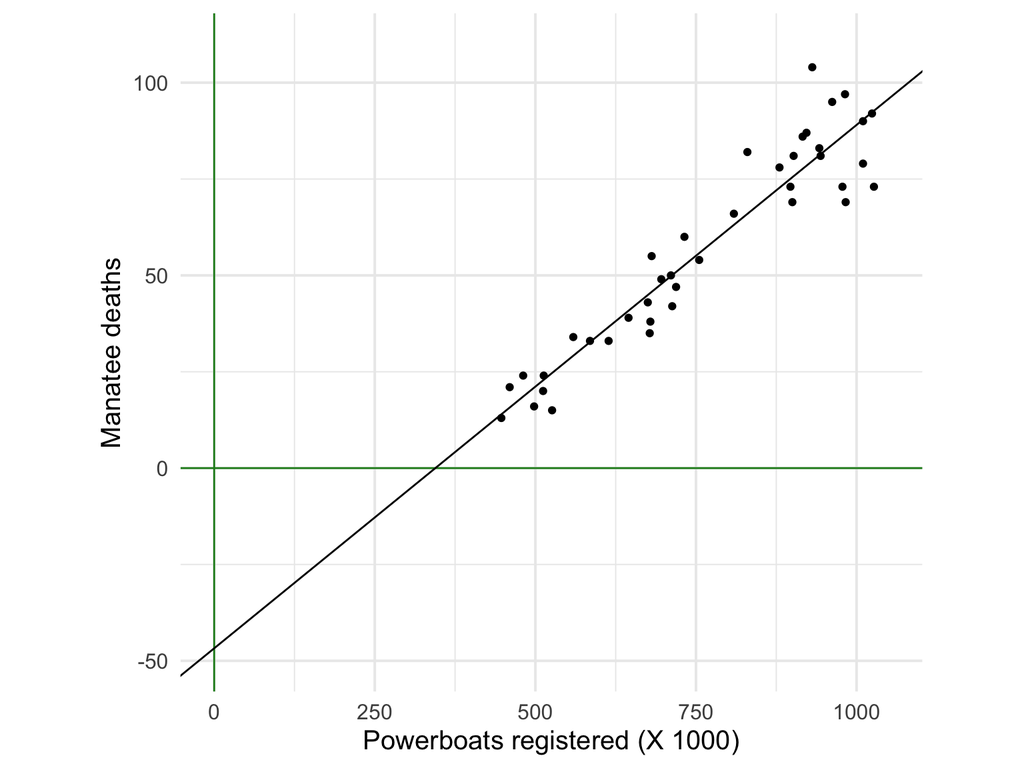

# R-squared

- When we run a linear model, the r-squared is also calculated.
- `glance()` is a function from `broom`. It shows the r-squared for the manatee data:

```r
glance(mana_lm)
```

```
## # A tibble: 1 × 12
##   r.squared adj.r.squared sigma statistic  p.value    df logLik   AIC   BIC
##       <dbl>         <dbl> <dbl>     <dbl>    <dbl> <dbl>  <dbl> <dbl> <dbl>
## 1     0.893         0.890  8.82      316. 5.21e-20     1  -143.  292.  297.
## # ℹ 3 more variables: deviance <dbl>, df.residual <int>, nobs <int>
```

Focus on:

- Column called `r.squared` only.
- Interpretation of r-squared: 89.3% of the variation in manatee deaths is explained by variation in the number of motorboats.

# High r-squared values in public health

An r-squared of 89.3% is very high! In public health, it would be rare for us to see an r-squared value so high when we have only one independent variable in the model.

One hypothetical example in public health that may have a high r-squared is:

- x-value: % of the population who are vaccinated against HPV each year
- y-value: Incidence of new cases of cervical cancer each year among the vaccine-eligible population

Because 91% of cervical cancer is estimated to be caused HPV, as vaccination against HPV increases, the number of new cases of cervical cancer will go down and be strongly related to the % vaccinated. If this relationship were linear (we would need to check the plot for linearity!), we would anticipate its r-squared value to be high.

# Example using transformed data

- Sometimes, the data is transformed to another scale so that the relationship between the transformed $x$ and $y$ is linear
- Table 3.4 in the textbook provides data on the mean number of seeds produced in a year by several common tree species and the mean weight (im milligrams) of the seeds produced.

```r
# Students, you don't need to know how to make a tibble data frame
# Just know how to look at this code and see that a data frame is being created.
library(tibble)
seed_data <- tribble(~ species, ~ seed_count, ~ seed_weight,
                       "Paper birch", 27239, 0.6,
                       "Yellow birch", 12158, 1.6,
                       "White spruce", 7202, 2.0,
                       "Engelman spruce", 3671, 3.3,
                       "Red spruce", 5051, 3.4,
                       "Tulip tree", 13509, 9.1,
                       "Ponderosa pine", 2667, 37.7,
                       "White fir", 5196, 40.0,
                       "Sugar maple", 1751, 48.0,
                       "Sugar pine", 1159, 216.0,
                       "American beech", 463, 247,
                       "American beech", 1892, 247,
                       "Black oak", 93, 1851,
                       "Scarlet oak", 525, 1930,
                       "Red oak", 411, 2475,
                       "Red oak", 253, 2475,
                       "Pignut hickory", 40, 3423,
                       "White oak", 184, 3669,
                       "Chestnut oak", 107, 4535)
```

# Scatter plot of `seed_weight` vs. `seed_count`

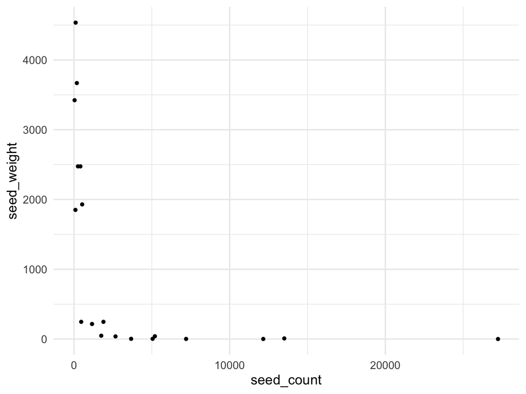

```r
ggplot(seed_data, aes(seed_count, seed_weight)) +
  geom_point() +
  theme_minimal(base_size = 15)
```

- `seed_count` and `seed_weight` both vary widely
- Their relationship is not linear

# Investigate the relationship between their logged variables

- Add transformed variables to the dataset using `mutate()`.
- We add both log base $e$ and log base 10 variables for illustration

```r
library(dplyr)
seed_data <- seed_data %>% mutate(log_seed_count = log(seed_count),  # base e
                                  log_seed_weight = log(seed_weight), # base e
                                  log_b10_count = log(seed_count, 10), # base 10
                                  log_b10_weight = log(seed_weight, 10)) # base 10
```

# Plot transformed data (log base e)

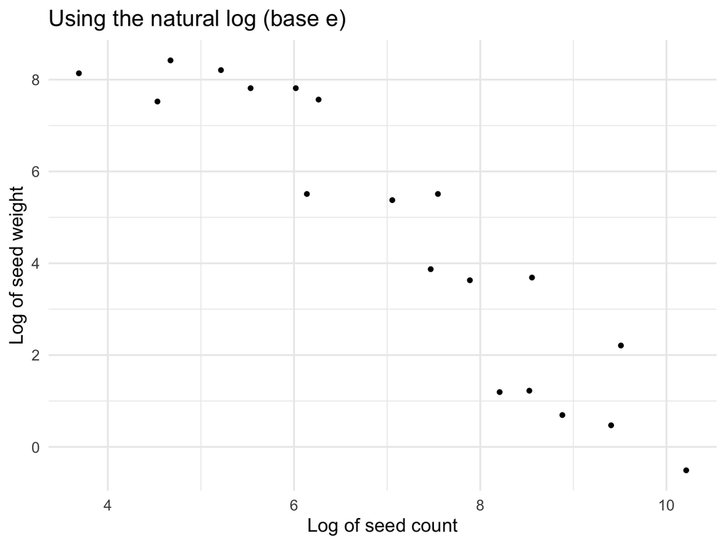

```r
ggplot(seed_data, aes(log_seed_count, log_seed_weight)) +
  geom_point() +
  labs(x = "Log of seed count", y = "Log of seed weight",
       title = "Using the natural log (base e)") +
  theme_minimal(base_size = 15)
```

# Plot transformed data (log base 10)

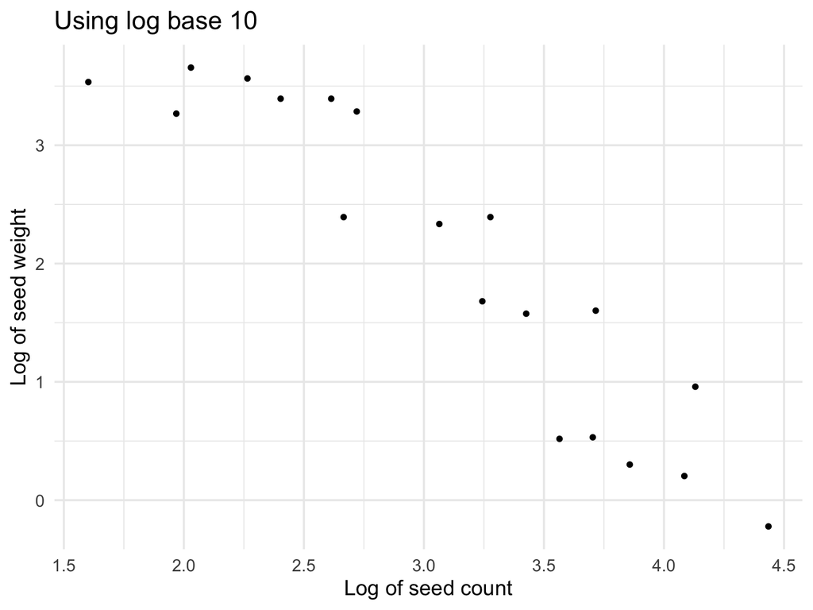

```r
ggplot(seed_data, aes(log_b10_count, log_b10_weight)) +
  geom_point() +
  labs(x = "Log of seed count", y = "Log of seed weight",
       title = "Using log base 10") +
  theme_minimal(base_size = 15)
```

- You can use either base 10 or base $e$ for class.
- The calculations using base $e$ are easier

# What happens if we only transform one of the variables here?

What is the relationship between the log of seed count and seed weight (not-logged)?

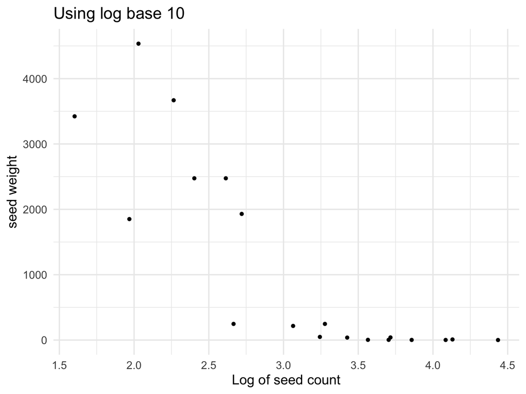

```r
ggplot(seed_data, aes(log_b10_count, seed_weight)) +
  geom_point() +
  labs(x = "Log of seed count", y = "seed weight",
       title = "Using log base 10") +
  theme_minimal(base_size = 15)
```

For these specific variables, just transforming one of them does not make the relationship between the variables linear. We needed to transform both x and y for the relationship to be linear.

Be careful! You don’t always need to transform both x and y variables! Sometimes you need to only transform x or only transform y. To figure this out, try different combinations of transformations and plotting them. Pick the set up such that the plot shows a linear relationship

# `lm()` on the log (base e) variables

```r
seed_mod <- lm(log_seed_weight ~ log_seed_count, data = seed_data)
tidy(seed_mod)
```

```
## # A tibble: 2 × 5
##   term           estimate std.error statistic  p.value
##   <chr>             <dbl>     <dbl>     <dbl>    <dbl>
## 1 (Intercept)       15.5      1.08       14.3 6.37e-11
## 2 log_seed_count    -1.52     0.147     -10.4 9.28e- 9
```

```r
glance(seed_mod) %>% pull(r.squared)
```

```
## [1] 0.8631177
```

- Interpret the intercept:
- Interpret the slope:

# `lm()` on the log (base e) variables

```r
seed_mod <- lm(log_seed_weight ~ log_seed_count, data = seed_data)
tidy(seed_mod)
```

```
## # A tibble: 2 × 5
##   term           estimate std.error statistic  p.value
##   <chr>             <dbl>     <dbl>     <dbl>    <dbl>
## 1 (Intercept)       15.5      1.08       14.3 6.37e-11
## 2 log_seed_count    -1.52     0.147     -10.4 9.28e- 9
```

```r
glance(seed_mod) %>% pull(r.squared)
```

```
## [1] 0.8631177
```

- Interpret the intercept: When the natural log of the number of seeds is zero, the natural log of the weight of the seeds is estimated to be 15.5 milligrams.
- Interpret the slope: A one unit change in the natural log of the number of seeds is associated with a 1.52 unit decrease in the natural log of the weight of the seeds in milligrams
- Does the intercept interpretation make any sense in this context?

# `lm()` on the log (base 10) variables

```r
seed_mod_b10 <- lm(log_b10_weight ~ log_b10_count, data = seed_data)
tidy(seed_mod_b10)
```

```
## # A tibble: 2 × 5
##   term          estimate std.error statistic  p.value
##   <chr>            <dbl>     <dbl>     <dbl>    <dbl>
## 1 (Intercept)       6.73     0.469      14.3 6.37e-11
## 2 log_b10_count    -1.52     0.147     -10.4 9.28e- 9
```

```r
glance(seed_mod_b10) %>% pull(r.squared)
```

```
## [1] 0.8631177
```

- What is different from the log base $e$ output?

# Interpretation of `lm()` when using log (base $e$) data

- We use the results of the `lm()` on the log (base $e$) transformed data for making predictions
- E.g., what seed weight is predicted for a seed count of 2000?
- Worked calculation:
1. Write down the line of best fit: $log_e(seed.weight) = 15.49130 - 1.522220\times{log_e(seed.count)}$
2. Plug in $seed.count = 2000$ into the line of best fit: $log_e(seed.weight) = 15.49130 - 1.522220\times{log_e(2000)}$
3. Solve for seed count by exponentiating both sides:
   $$seed.weight = exp(15.49130 -
   1.522220\times{log_e(2000)})$$
   (this uses the property that $e^{log_e(x)}=x$)
   $$seed.weight = 50.45$$
4. Interpret: Seeds are expected to weigh 50.45 mg for trees having a seed count of 2000.

**Make sure you can do this worked calculation on a calculator or using R.**

# How do outliers affect the line of best fit?

To study this, we use data from the Organisation for Economic Co-operation and Development (OECD). This dataset was downloaded from http://dx.doi.org/10.1787/888932526084 and contains information on the health expenditure per capita and the GDP per capita for 40 countries.

```r
library(readxl)

spending_dat <- read_xlsx("./data/Ch04_Country-healthcare-spending.xlsx",
                          sheet = 2,
                          range = "A7:D47")
```

# Have a look

Next, we want to examine the imported data to see if it is how we expect:

```r
str(spending_dat)
```

```
## tibble [40 × 4] (S3: tbl_df/tbl/data.frame)
##  $ Country                      : chr [1:40] "Australia" "Austria" "Belgium" "Brazil" ...
##  $ Country.code                 : chr [1:40] "AUS" "AUT" "BEL" "BRA" ...
##  $ Health expenditure per capita: num [1:40] 3445 4289 3946 943 4363 ...
##  $ GDP per capita               : num [1:40] 39409 38823 36287 10427 38230 ...
```

```r
head(spending_dat)
```

```
## # A tibble: 6 × 4
##   Country   Country.code `Health expenditure per capita` `GDP per capita`
##   <chr>     <chr>                                  <dbl>            <dbl>
## 1 Australia AUS                                     3445            39409
## 2 Austria   AUT                                     4289            38823
## 3 Belgium   BEL                                     3946            36287
## 4 Brazil    BRA                                      943            10427
## 5 Canada    CAN                                     4363            38230
## 6 Chile     CHL                                     1186            14131
```

# Rename() some variables to use a consistent naming style

If the variable name has spaces, we must use back ticks when referring to it:

```r
library(dplyr)
spending_dat <- spending_dat %>%
  rename(country_code = Country.code,
         health_expenditure = `Health expenditure per capita`, # back ticks
         GDP = `GDP per capita`) # back ticks
```

# Examine the relationship

Make a scatter plot of `health_expenditure` (our response variable) vs. each country’s level of `GDP`:

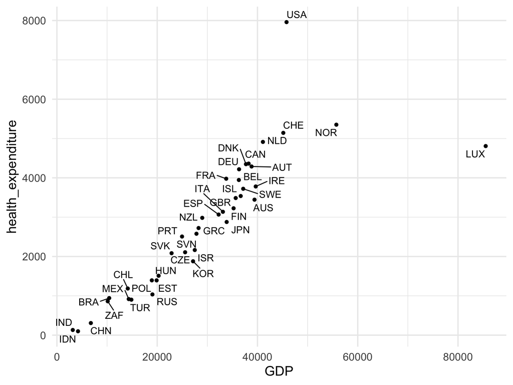

```r
#install.packages("ggrepel")
library(ggrepel) #this library is used for adding labels to a scatter plot that don't overlap the data points

ggplot(spending_dat, aes(x = GDP, y = health_expenditure)) +
  geom_point() +
  geom_text_repel(aes(label = country_code)) +
  theme_minimal(base_size = 15)
```

# Examine the relationship

Is the relationship linear? Which countries are outliers?

Fit a linear model to these data and add it to the graph:

```r
lm(health_expenditure ~ GDP, data = spending_dat)
```

```
##
## Call:
## lm(formula = health_expenditure ~ GDP, data = spending_dat)
##
## Coefficients:
## (Intercept)          GDP
##    44.65623      0.09399
```

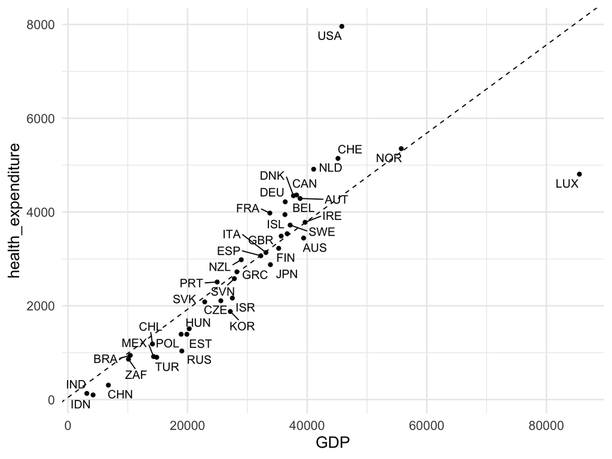

```r
ggplot(spending_dat, aes(x = GDP, y = health_expenditure)) +
  geom_point() +
  geom_text_repel(aes(label = country_code)) + # this adds the country code as a label
  geom_abline(intercept = 44.65623, slope = 0.09399, lty = 2) +
  theme_minimal(base_size = 15)
```

# Examine the relationship without Luxembourg in the data

Let’s see whether removing Luxembourg changes the fit of the line. We can remove Luxembourg using the `filter()` command from `dplyr`:

```r
spending_dat_no_LUX <- spending_dat %>% filter(country_code != "LUX")

lm(health_expenditure ~ GDP, data = spending_dat_no_LUX)
```

```
##
## Call:
## lm(formula = health_expenditure ~ GDP, data = spending_dat_no_LUX)
##
## Coefficients:
## (Intercept)          GDP
##   -785.1044       0.1264
```

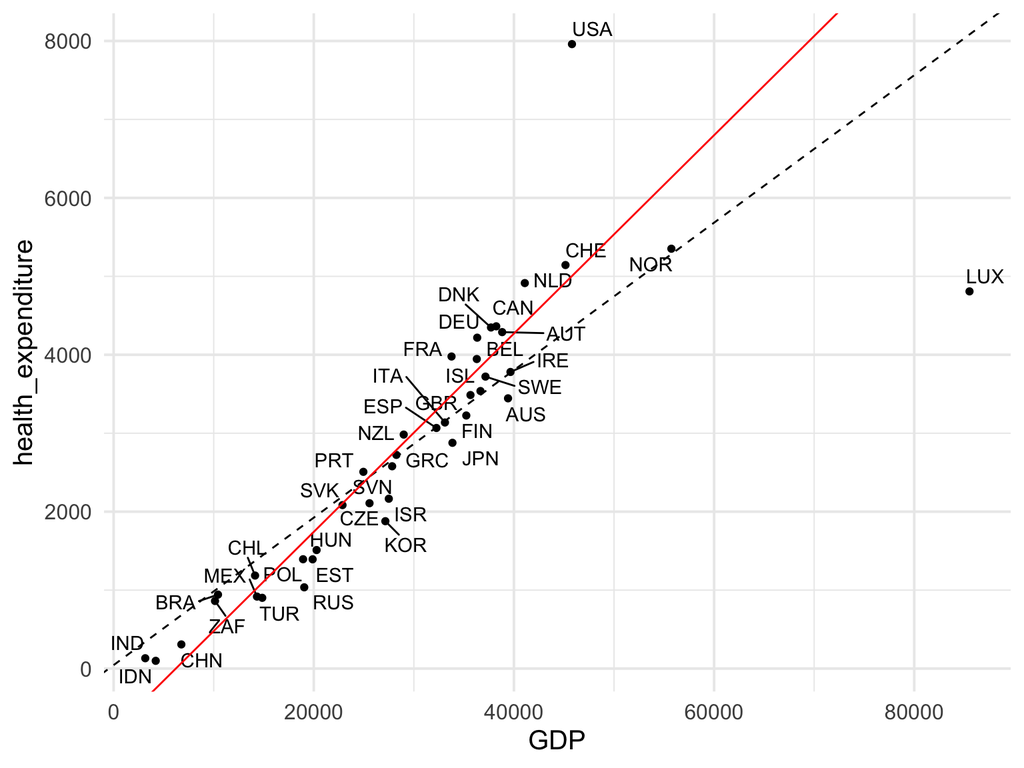

```r
ggplot(spending_dat, aes(x = GDP, y = health_expenditure)) + geom_point() +
  geom_text_repel(aes(label = country_code)) +
  geom_abline(intercept = 44.65623, slope = 0.09399, lty = 2) +
  geom_abline(intercept = -785.1044, slope = 0.1264, col = "red") +
  theme_minimal(base_size = 15)
```

# Examine the relationship without USA in the data

```r
spending_dat_no_USA <- spending_dat %>% filter(country_code != "USA")

lm(health_expenditure ~ GDP, data = spending_dat_no_USA)
```

```
##
## Call:
## lm(formula = health_expenditure ~ GDP, data = spending_dat_no_USA)
##
## Coefficients:
## (Intercept)          GDP
##   152.26274      0.08714
```

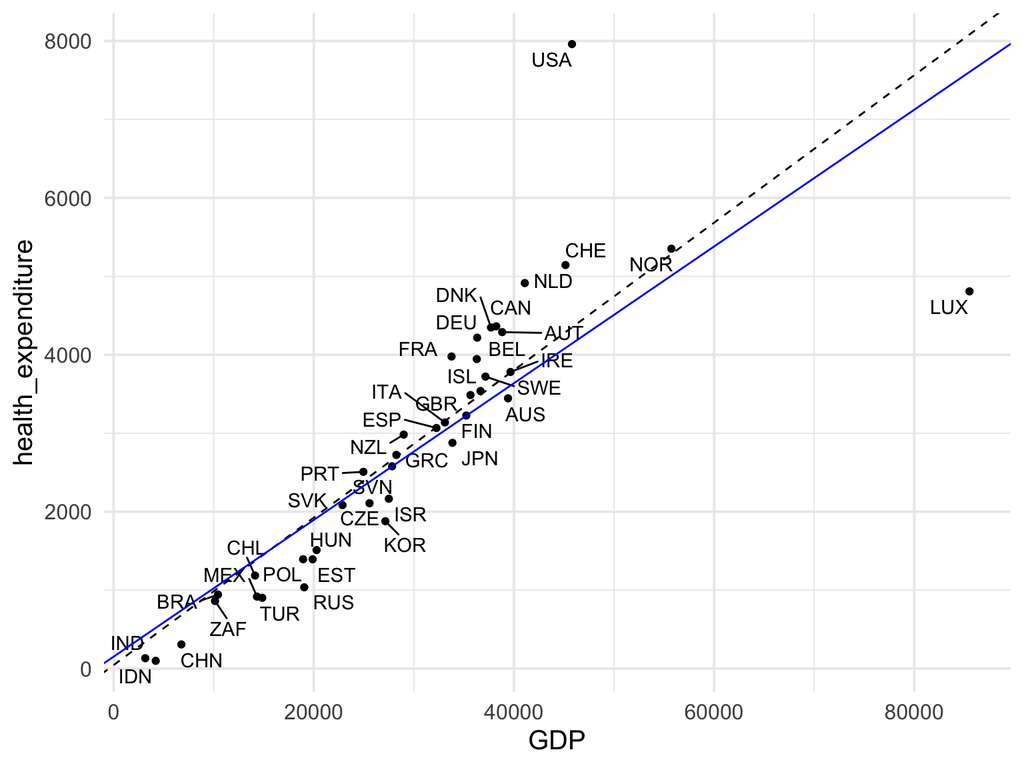

```r
ggplot(spending_dat, aes(x = GDP, y = health_expenditure)) + geom_point() +
  geom_text_repel(aes(label = country_code)) +
  geom_abline(intercept = 44.65623, slope = 0.09399, lty = 2) +
  geom_abline(intercept = 152.26274, slope = 0.08714, col = "blue") +
  theme_minimal(base_size = 15)
```

# Examine the relationship without LUX or USA in the data

Let’s write the code together to remove both the USA and LUX and see how it affects the fit:

```r
spending_dat_no_USA_LUX <- spending_dat %>% filter(country_code != "USA" & country_code != "LUX")

#alternatively, you could have written:
spending_dat_no_USA_LUX <- spending_dat %>% filter(! country_code %in% c("USA", "LUX"))

#pick the filter command that makes the most sense to you.

lm(health_expenditure ~ GDP, data = spending_dat_no_USA_LUX)
```

```
##
## Call:
## lm(formula = health_expenditure ~ GDP, data = spending_dat_no_USA_LUX)
##
## Coefficients:
## (Intercept)          GDP
##   -592.6973       0.1166
```

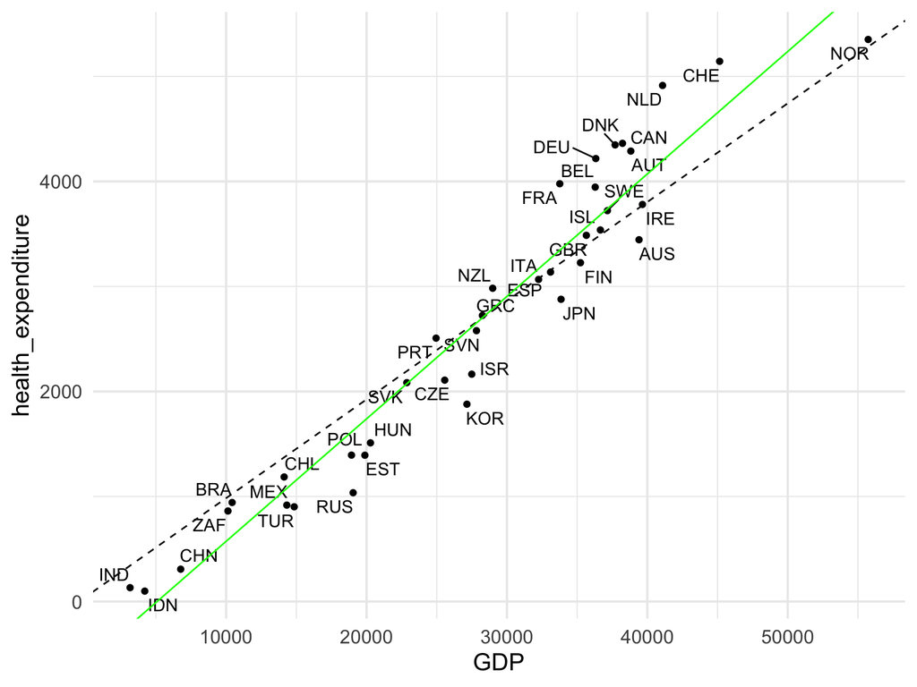

```r
ggplot(spending_dat_no_USA_LUX, aes(x = GDP, y = health_expenditure)) + geom_point() +
  geom_text_repel(aes(label = country_code)) +
  geom_abline(intercept = 44.65623, slope = 0.09399, lty = 2) +
  geom_abline(intercept = -592.6973, slope = 0.1166 , col = "green") +
  theme_minimal(base_size = 15)
```

What would happen if USA’s point had actually been along the original line of best fit (say at x = 80000 and y = 7500) and we re-fit the line without USA’s point? Would USA have been an **outlier**? Would it be considered **influential**?

# But, is it causal?

- Creating a scatter plot and a simple linear model is an important step in many analyses. It allows you to see the relationship between two quantatitive variables and estimate the line of best fit.
- Sometimes these relationships will be used to make claims of causality. Baldi & Moore emphasize that experiments are the best way to study causality. While this is often true, sophisticated causal methods have been developed for the analysis of observational data.

# Discussion of some examples from Baldi & Moore

**Example 4.7 “Nature, nuture, and lurking variables”** presents an advertisement from the Michigan Symphony:

“Question: Which students scored 51 points higher in verbal skills and 39 points higher in math?

Answer: Students who had experience in music.”

Marketers often make leading statements that make their product or service sound appealing. The purpose of this ad was to have the target audience impute that music causes higher marks at school because there is an association between enrollment in music and higher marks. However, are students enrolled in music lessons otherwise the same as students not enrolled in music lessons? What else do you expect to differ between these groups of students?

# Discussion of some examples from Baldi & Moore

We can encode these differences in a causal diagram. Here is a simple one to demonstrate the concept:

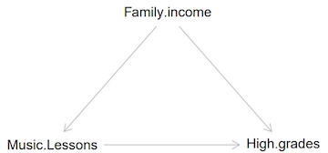

The forking at the “Family Income” node makes explicit that we believe family income to be a confounder of the relationship between taking music lessons and achieving higher grades. It means that not only do these children take music lessons, they also come from families with higher incomes, and higher incomes lead to higher grades in other ways. Of course, family income is not the only possible confounder. What are some others?

# Confounding

In this course, we don’t address how to control for confounding or other types of bias that limit causal interpretations. However, know that causality can be studied using observational data and relies on clever study designs and oftentimes on advanced methods.